# Bristol Bay Temperature Data Summary

# Cook Inletkeeper

```r
cik.data <- daily.dat2 %>% filter(Source == "CIK")

cik.data.summary <- cik.data %>%
  mutate(year = year(sampleDate)) %>%
  group_by(SiteID, year) %>%
  summarize(meanTemp = mean(meanDT, na.rm = T),
            maxTemp = max(meanDT, na.rm = T),
            minTemp = min(meanDT, na.rm = T),
            sdTemp = sd(meanDT, na.rm = T),
            n_obs = n())

cik.data.summary %>%
  datatable() %>%
  formatRound(columns=c("meanTemp","maxTemp","minTemp","sdTemp"), digits=2)
```

|  | SiteID | year | meanTemp | maxTemp | minTemp | sdTemp | n_obs |
| --- | --- | --- | --- | --- | --- | --- | --- |
| 1 | CIK_Ben Courtney Creek | 2017 | 12.9779935897436 | 18.2266666666667 | 5.23116666666667 | 2.77393391937937 | 104 |
| 2 | CIK_Ben Courtney Creek | 2018 | 12.8147664141414 | 17.2570208333333 | 8.11680208333333 | 1.96956796884977 | 99 |
| 3 | CIK_Ben Courtney Creek | 2019 | 14.874064162234 | 22.415375 | 6.38508333333333 | 3.64983852122755 | 94 |
| 4 | CIK_Big Creek | 2014 | 8.07537648809524 | 10.5220833333333 | 3.6999375 | 1.52266053248505 | 105 |
| 5 | CIK_Big Creek | 2015 | 8.35671917691257 | 11.1367083333333 | 3.38570833333333 | 1.98533801799075 | 122 |
| 6 | CIK_Copper River | 2017 | 12.9152510245902 | 17.736875 | 7.609375 | 2.30723356476517 | 122 |
| 7 | CIK_Copper River | 2018 | 11.8375765027322 | 15.64875 | 8.07633333333333 | 1.6282387198384 | 122 |
| 8 | CIK_Gibraltar River | 2017 | 11.1306704234973 | 14.5095416666667 | 7.73091666666667 | 1.72141322745463 | 122 |
| 9 | CIK_Gibraltar River | 2018 | 10.4524415983607 | 13.2396666666667 | 5.20016666666667 | 1.77821637138459 | 122 |
| 10 | CIK_Napotoli Creek | 2014 | 10.34824375 | 14.0307916666667 | 4.16744791666667 | 2.14582027578121 | 110 |

[output cut: 28 more lines]

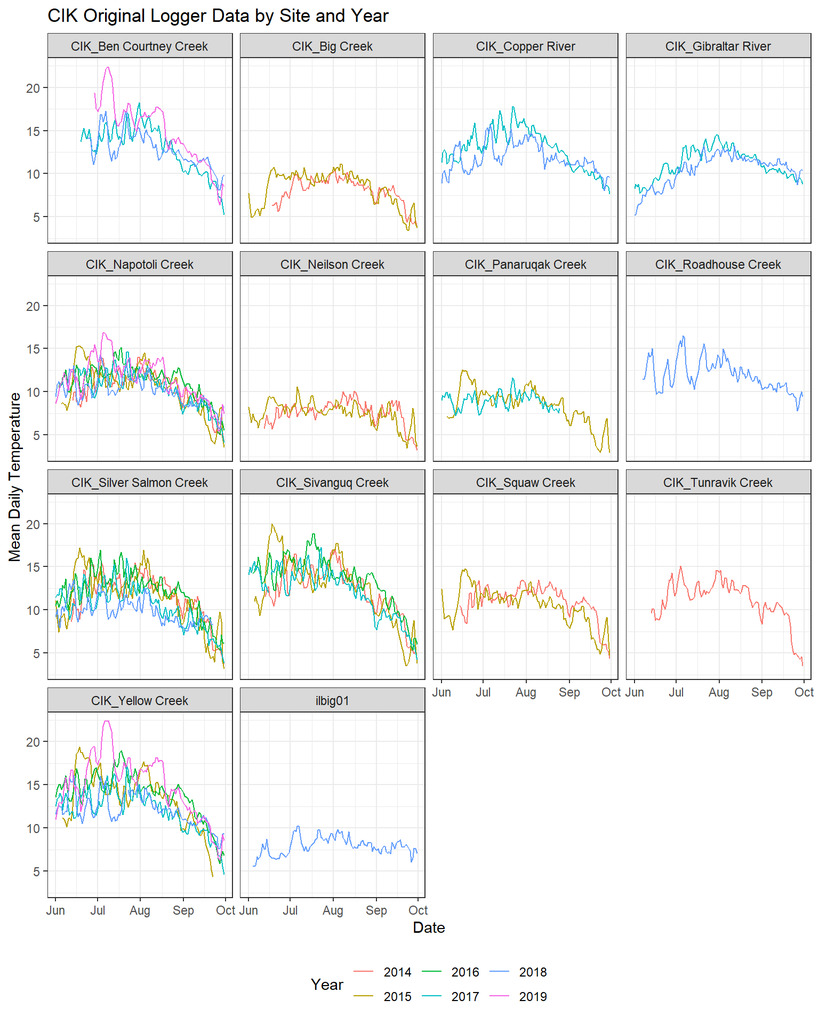

```r
cik.data %>%
  complete(SiteID, sampleDate = seq.Date(min(sampleDate), max(sampleDate), by = "day")) %>%
  mutate(year = year(sampleDate),
         mo_day = format(sampleDate, "%m-%d")) %>%
  ggplot(aes(x = as.Date(mo_day, format = "%m-%d"), y = meanDT, color = as.factor(year))) +
  geom_line() +
  scale_x_date(date_breaks = "1 months", date_labels = "%b", limits = c(as.Date("06-01", format = "%m-%d"), as.Date("09-30", format = "%m-%d"))) +
  facet_wrap(~ SiteID) +
  labs(x = "Date", y = "Mean Daily Temperature", color = "Year",
       title = "CIK Original Logger Data by Site and Year") +
  theme_bw() +
  theme(legend.position = "bottom")
```

# ACCS

```r
accs.data <- daily.dat2 %>% filter(Source == "UAA")

accs.data.summary <- accs.data %>%
  mutate(year = year(sampleDate)) %>%
  group_by(SiteID, Waterbody_name, year) %>%
  summarize(meanTemp = mean(meanDT, na.rm = T),
            maxTemp = max(meanDT, na.rm = T),
            minTemp = min(meanDT, na.rm = T),
            sdTemp = sd(meanDT, na.rm = T),
            n_obs = n())

accs.data.summary %>%
  datatable() %>%
  formatRound(columns=c("meanTemp","maxTemp","minTemp","sdTemp"), digits=2)
```

|  | SiteID | Waterbody_name | year | meanTemp | maxTemp | minTemp | sdTemp | n_obs |
| --- | --- | --- | --- | --- | --- | --- | --- | --- |
| 1 | AKBB-011 | Victoria Creek | 2015 | 9.07899824719551 | 13.9366770833333 | 1.798 | 2.86642433823118 | 104 |
| 2 | AKBB-011 | Victoria Creek | 2016 | 10.2548048298042 | 13.99375 | 3.13884375 | 2.20778809018279 | 122 |
| 3 | AKBB-011 | Victoria Creek | 2017 | 9.02252819387053 | 13.3495625 | 2.87065625 | 2.12648897592671 | 121 |
| 4 | AKBB-011 | Victoria Creek | 2018 | 9.35075804924243 | 13.3908229166667 | 5.18305208333333 | 1.86266456791353 | 121 |
| 5 | AKBB-011 | Victoria Creek | 2019 | 10.4149059917355 | 15.51671875 | 3.45727083333333 | 2.67912864008934 | 121 |
| 6 | AKBB-020 | Little Mulchatna River | 2015 | 13.7218551274272 | 18.923953125 | 5.93569270833333 | 3.31719812774066 | 103 |
| 7 | AKBB-020 | Little Mulchatna River | 2016 | 14.0513601647882 | 17.5931197916667 | 8.32927083333333 | 2.13285112944785 | 122 |
| 8 | AKBB-020 | Little Mulchatna River | 2017 | 13.2564567837466 | 17.0151666666667 | 7.79219791666667 | 2.46078966135013 | 121 |
| 9 | AKBB-020 | Little Mulchatna River | 2018 | 12.7095936639118 | 17.53065625 | 5.093625 | 2.1709205362753 | 121 |
| 10 | AKBB-020 | Little Mulchatna River | 2019 | 15.2285383953168 | 23.018375 | 7.9039375 | 3.55198773705903 | 121 |

[output cut: 68 more lines]

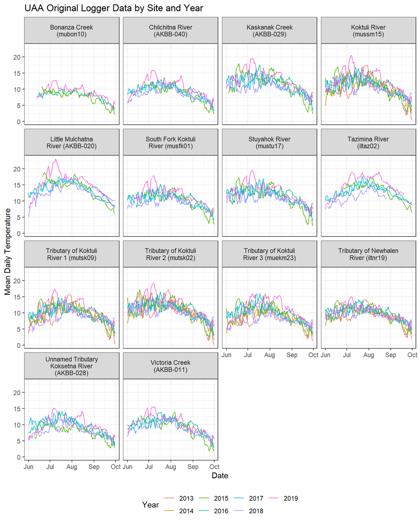

```r
accs.data %>%
  mutate(facetLabel = paste0(Waterbody_name, " (", SiteID, ")")) %>%
  complete(facetLabel, sampleDate = seq.Date(min(sampleDate), max(sampleDate), by = "day")) %>%
  mutate(year = year(sampleDate),
         mo_day = format(sampleDate, "%m-%d")) %>%
  ggplot(aes(x = as.Date(mo_day, format = "%m-%d"), y = meanDT, color = as.factor(year))) +
  geom_line() +
  scale_x_date(date_breaks = "1 months", date_labels = "%b", limits = c(as.Date("06-01", format = "%m-%d"), as.Date("09-30", format = "%m-%d"))) +
  facet_wrap(~ facetLabel, labeller = label_wrap_gen(width = 22, multi_line = TRUE)) +
  labs(x = "Date", y = "Mean Daily Temperature", color = "Year",
       title = "UAA Original Logger Data by Site and Year") +
  theme_bw() +
  theme(legend.position = "bottom")
```

# NPS

Krista Bartz and Paul Gabriel provided data from 17 stream site and also data Dan Young collected at an additional five stream sites.

Note that there are additional lakeshore sites and also temperature data from depth arrays for 6 lakes, which are not shown here. All data have been reviewed or clipped to June 1 - Sept 30 per input from Krista. The summary table and figure are based on the surface depths only for the lake arrays. It looks like the 0 meter depth is not always available so we may need to use the next depth for some of our analyses.

```r
nps.data <- daily.dat2 %>% filter(Source == "NPS")

nps.data.summary <- nps.data %>%
  group_by(SiteID, Waterbody_name, Year) %>%
  summarize(meanTemp = mean(meanDT, na.rm = T),
            maxTemp = max(meanDT, na.rm = T),
            minTemp = min(meanDT, na.rm = T),
            sdTemp = sd(meanDT, na.rm = T),
            n_obs = n())

nps.data.summary %>%
  datatable() %>%
  formatRound(columns=c("meanTemp","maxTemp","minTemp","sdTemp"), digits=2)
```

|  | SiteID | Waterbody_name | Year | meanTemp | maxTemp | minTemp | sdTemp | n_obs |
| --- | --- | --- | --- | --- | --- | --- | --- | --- |
| 1 | KATM_idavc_stream_water | Idavain Creek | 2017 | 12.9971174863388 | 18.7516666666667 | 6.10208333333333 | 2.60878046804933 | 122 |
| 2 | KATM_idavc_stream_water | Idavain Creek | 2018 | 12.7315570355191 | 17.7987083333333 | 8.61604166666667 | 1.89928957299662 | 122 |
| 3 | KATM_idavc_stream_water | Idavain Creek | 2019 | 15.2146442890235 | 22.8056666666667 | 6.95741666666667 | 3.44909225995293 | 122 |
| 4 | KATM_idavc_stream_water | Idavain Creek | 2020 | 14.5494942528736 | 17.8867083333333 | 9.48679166666667 | 1.6992937453213 | 87 |
| 5 | KATM_lbrooo_lvl | Lake Brooks | 2006 | 10.7259107669617 | 16.7096666666667 | 5.33333333333333 | 2.27795435076 | 113 |
| 6 | KATM_lbrooo_lvl | Lake Brooks | 2007 | 11.967868115942 | 19.3549166666667 | 5.7495 | 2.47830028071664 | 115 |
| 7 | KATM_lbrooo_lvl | Lake Brooks | 2008 | 10.7685097789116 | 15.3739583333333 | 5.96208333333333 | 2.38000559665284 | 98 |
| 8 | KATM_lbrooo_lvl | Lake Brooks | 2012 | 10.0910848348348 | 13.3440833333333 | 5.86683333333333 | 1.82221124377732 | 111 |
| 9 | KATM_lbrooo_lvl | Lake Brooks | 2013 | 12.8552898550725 | 20.022 | 6.64245833333333 | 2.81693561226489 | 115 |
| 10 | KATM_lbrooo_lvl | Lake Brooks | 2015 | 12.8645887978142 | 17.634 | 8.27129166666667 | 2.28780965544352 | 122 |

[output cut: 108 more lines]

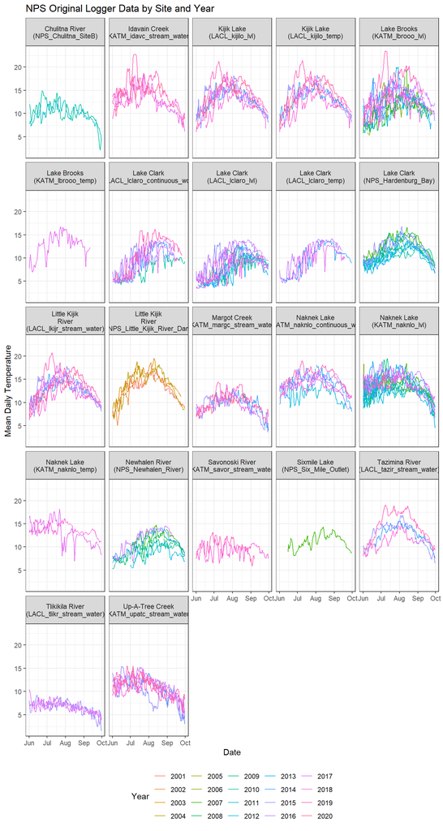

```r
nps.data %>%
  mutate(facetLabel = paste0(Waterbody_name, " (", SiteID, ")")) %>%
  complete(facetLabel, sampleDate = seq.Date(min(sampleDate), max(sampleDate), by = "day")) %>%
  mutate(year = year(sampleDate),
         mo_day = format(sampleDate, "%m-%d")) %>%
  ggplot(aes(x = as.Date(mo_day, format = "%m-%d"), y = meanDT, color = as.factor(year))) +
  geom_line() +
  scale_x_date(date_breaks = "1 months", date_labels = "%b", limits = c(as.Date("06-01", format = "%m-%d"), as.Date("09-30", format = "%m-%d"))) +
  facet_wrap(~ facetLabel, labeller = label_wrap_gen(width = 18, multi_line = TRUE)) +
  labs(x = "Date", y = "Mean Daily Temperature", color = "Year",
       title = "NPS Original Logger Data by Site and Year") +
  theme_bw() +
  theme(legend.position = "bottom")
```

# USFWS

```r
fws.data <- daily.dat2 %>% filter(Source == "FWS")

fws.data.summary <- fws.data %>%
  group_by(SiteID, Waterbody_name, Year) %>%
  summarize(meanTemp = mean(meanDT, na.rm = T),
            maxTemp = max(meanDT, na.rm = T),
            minTemp = min(meanDT, na.rm = T),
            sdTemp = sd(meanDT, na.rm = T),
            n_obs = n())

fws.data.summary %>%
  datatable() %>%
  formatRound(columns=c("meanTemp","maxTemp","minTemp","sdTemp"), digits=2)
```

|  | SiteID | Waterbody_name | Year | meanTemp | maxTemp | minTemp | sdTemp | n_obs |
| --- | --- | --- | --- | --- | --- | --- | --- | --- |
| 1 | 580223156504200 | Egegik River | 2015 | 10.3107821038251 | 13.4425 | 6.815 | 1.77115612969302 | 122 |
| 2 | 580223156504200 | Egegik River | 2016 | 11.7610020661157 | 14.61875 | 7.90635416666667 | 1.88233877527712 | 121 |
| 3 | 580223156504200 | Egegik River | 2017 | 9.25711407103825 | 12.94125 | 6.56166666666667 | 1.61160848192511 | 122 |
| 4 | 580223156504200 | Egegik River | 2018 | 9.55642759562842 | 11.615 | 5.69458333333333 | 1.26536928800509 | 122 |
| 5 | GELO | Gechiak River | 2003 | 13.3695199275362 | 19.545 | 5.94958333333333 | 3.0612936263416 | 122 |
| 6 | GELO | Gechiak River | 2004 | 14.3775493905002 | 22.25875 | 4.06291666666667 | 4.07434554528106 | 122 |
| 7 | GELO | Gechiak River | 2005 | 14.5006288607745 | 20.675 | 7.93166666666667 | 3.42846772726777 | 122 |
| 8 | GELO | Gechiak River | 2006 | 12.3852117486339 | 19.025 | 3.54583333333333 | 3.41701459301781 | 122 |
| 9 | GELO | Gechiak River | 2007 | 13.0547506830601 | 18.2258333333333 | 7.01416666666667 | 2.81372333697629 | 122 |
| 10 | GELO | Gechiak River | 2008 | 12.070843579235 | 17.3879166666667 | 2.69916666666667 | 3.03566958251894 | 122 |

[output cut: 131 more lines]

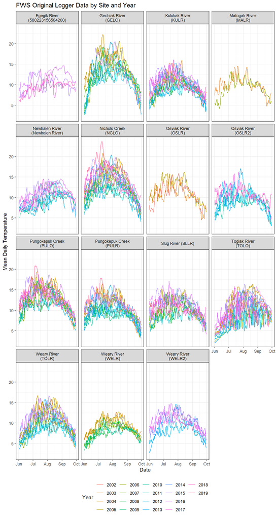

```r
fws.data %>%
  mutate(facetLabel = paste0(Waterbody_name, " (", SiteID, ")")) %>%
  complete(facetLabel, sampleDate = seq.Date(min(sampleDate), max(sampleDate), by = "day")) %>%
  mutate(year = year(sampleDate),
         mo_day = format(sampleDate, "%m-%d")) %>%
  ggplot(aes(x = as.Date(mo_day, format = "%m-%d"), y = meanDT, color = as.factor(year))) +
  geom_line() +
  scale_x_date(date_breaks = "1 months", date_labels = "%b", limits = c(as.Date("06-01", format = "%m-%d"), as.Date("09-30", format = "%m-%d"))) +
  facet_wrap(~ facetLabel, labeller = label_wrap_gen(width = 18, multi_line = TRUE)) +
  labs(x = "Date", y = "Mean Daily Temperature", color = "Year",
       title = "FWS Original Logger Data by Site and Year") +
  theme_bw() +
  theme(legend.position = "bottom")
```

# UW

```r
uw.data <- daily.dat2 %>% filter(Source == "UW")

uw.data.summary <- uw.data %>%
  group_by(SiteID, Year) %>%
  summarize(meanTemp = mean(meanDT, na.rm = T),
            maxTemp = max(meanDT, na.rm = T),
            minTemp = min(meanDT, na.rm = T),
            sdTemp = sd(meanDT, na.rm = T),
            n_obs = n())

uw.data.summary %>%
  datatable() %>%
  formatRound(columns=c("meanTemp","maxTemp","minTemp","sdTemp"), digits=2)
```

|  | SiteID | Year | meanTemp | maxTemp | minTemp | sdTemp | n_obs |
| --- | --- | --- | --- | --- | --- | --- | --- |
| 1 | UW_Agulowak River | 2014 | 13.6365067829457 | 16.4270833333333 | 9.09375 | 1.36740795171291 | 86 |
| 2 | UW_Agulowak River | 2017 | 12.9411221590909 | 15.9086666666667 | 9.16208333333333 | 1.30206052200394 | 88 |
| 3 | UW_Agulukpak River | 2011 | 9.36215277777778 | 14.703125 | 4.5234375 | 3.14963632205539 | 90 |
| 4 | UW_Agulukpak River | 2016 | 14.9387408854167 | 18.8978333333333 | 5.41895833333333 | 2.96092162975011 | 96 |
| 5 | UW_Agulukpak River | 2019 | 15.3430894498987 | 22.5799583333333 | 6.14525 | 3.70500520977492 | 93 |
| 6 | UW_Aleknagik Bear Creek | 2011 | 5.78790760869565 | 8.15625 | 3.0625 | 1.05255315096237 | 92 |
| 7 | UW_Aleknagik Bear Creek | 2012 | 6.17319587628866 | 8.3 | 3.8 | 0.874108529674367 | 97 |
| 8 | UW_Aleknagik Bear Creek | 2013 | 6.80772277227723 | 9.57 | 1.72 | 1.53030708107106 | 101 |
| 9 | UW_Aleknagik Bear Creek | 2014 | 7.58408416669 | 9.780708333 | 5.204291667 | 1.04727348246418 | 100 |
| 10 | UW_Aleknagik Bear Creek | 2015 | 8.23863448845545 | 9.574375 | 5.722041667 | 0.763701708336338 | 101 |

[output cut: 259 more lines]

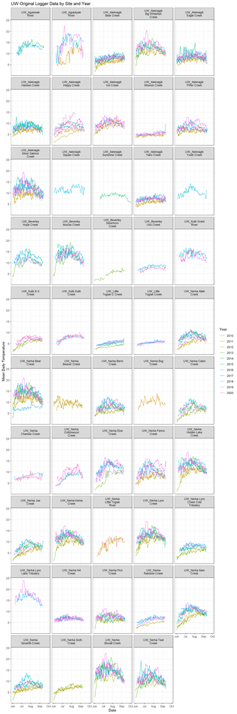

```r
uw.data %>%
  complete(SiteID, sampleDate = seq.Date(min(sampleDate), max(sampleDate), by = "day")) %>%
  mutate(year = year(sampleDate),
         mo_day = format(sampleDate, "%m-%d")) %>%
  ggplot(aes(x = as.Date(mo_day, format = "%m-%d"), y = meanDT, color = as.factor(year))) +
  geom_line() +
  scale_x_date(date_breaks = "1 months", date_labels = "%b", limits = c(as.Date("06-01", format = "%m-%d"), as.Date("09-30", format = "%m-%d"))) +
  facet_wrap(~ SiteID, labeller = label_wrap_gen(width = 15, multi_line = TRUE), ncol = 5) +
  labs(x = "Date", y = "Mean Daily Temperature", color = "Year") +
  theme_bw() +
  ggtitle("UW Original Logger Data by Site and Year")
```

# USGS

USGS sites were downloaded and filtered to Bristol Bay using the R dataRetrieval library.

```r
usgs.data <- daily.dat2 %>% filter(Source == "USGS")

usgs.data.summary <- usgs.data %>%
  group_by(SiteID, Waterbody_name, Year) %>%
  summarize(meanTemp = mean(meanDT, na.rm = T),
            maxTemp = max(meanDT, na.rm = T),
            minTemp = min(meanDT, na.rm = T),
            sdTemp = sd(meanDT, na.rm = T),
            n_obs = n())

usgs.data.summary %>%
  datatable() %>%
  formatRound(columns=c("meanTemp","maxTemp","minTemp","sdTemp"), digits=2)
```

|  | SiteID | Waterbody_name | Year | meanTemp | maxTemp | minTemp | sdTemp | n_obs |
| --- | --- | --- | --- | --- | --- | --- | --- | --- |
| 1 | 15298040 | CHULITNA R 5MI AB MOUTH NR PORT ALSWORTH AK | 2010 | 10.8073770491803 | 15.5 | 2.5 | 2.25671332843621 | 122 |
| 2 | 15298040 | CHULITNA R 5MI AB MOUTH NR PORT ALSWORTH AK | 2011 | 10.5371900826446 | 14.5 | 6 | 1.81103709843306 | 121 |
| 3 | 15298040 | CHULITNA R 5MI AB MOUTH NR PORT ALSWORTH AK | 2013 | 11.766393442623 | 19 | 3 | 3.65437834660314 | 122 |
| 4 | 15298040 | CHULITNA R 5MI AB MOUTH NR PORT ALSWORTH AK | 2014 | 11.7467213114754 | 16.7 | 4.7 | 2.6344878727075 | 122 |
| 5 | 15298040 | CHULITNA R 5MI AB MOUTH NR PORT ALSWORTH AK | 2015 | 12.2926229508197 | 18.9 | 3.2 | 3.75755257151957 | 122 |
| 6 | 15298040 | CHULITNA R 5MI AB MOUTH NR PORT ALSWORTH AK | 2016 | 12.8534482758621 | 18.2 | 5.5 | 2.70099598488129 | 116 |
| 7 | 15298040 | CHULITNA R 5MI AB MOUTH NR PORT ALSWORTH AK | 2017 | 12.3358333333333 | 18 | 5.4 | 2.75631576758619 | 120 |
| 8 | 15300100 | BEAR C NR ILIAMNA AK | 2006 | 11.8975409836066 | 17.5 | 5.5 | 2.10070681197465 | 122 |
| 9 | 15300100 | BEAR C NR ILIAMNA AK | 2007 | 11.3975409836066 | 15.5 | 7 | 2.03272658622342 | 122 |
| 10 | 15300100 | BEAR C NR ILIAMNA AK | 2008 | 11.733606557377 | 15.5 | 6 | 2.04412525112105 | 122 |

[output cut: 69 more lines]

[figure not shown]

```r
usgs.data %>%
  mutate(facetLabel = paste0(Waterbody_name, " (", SiteID, ")")) %>%
  complete(facetLabel, sampleDate = seq.Date(min(sampleDate), max(sampleDate), by = "day")) %>%
  mutate(year = year(sampleDate),
         mo_day = format(sampleDate, "%m-%d")) %>%
  ggplot(aes(x = as.Date(mo_day, format = "%m-%d"), y = meanDT, color = as.factor(year))) +
  geom_line() +
  scale_x_date(date_breaks = "1 months", date_labels = "%b", limits = c(as.Date("06-01", format = "%m-%d"), as.Date("09-30", format = "%m-%d"))) +
  facet_wrap(~ facetLabel, labeller = label_wrap_gen(width = 18, multi_line = TRUE)) +
  labs(x = "Date", y = "Mean Daily Temperature", color = "Year",
       title = "USGS Original Logger Data by Site and Year") +
  theme_bw() +
  theme(legend.position = "bottom")
```